[figure not shown]

AFRICAST

Tidy time series & forecasting in R

# Basics of time series and data structures

Session 1 of 10

[figure not shown]

[figure not shown]

[figure not shown]

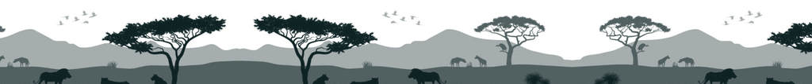

workshop.f4sg.org/africastForecasting for Social Good

## Outline

- Introduction to forecasting
- Time series data
- tsibble objects
- Example: Australian prison population
- Example: Australian pharmaceutical sales

# Introduction to forecasting

## What is a forecast?

Estimating how a sequence of observations will continue into the future, using all information available now.

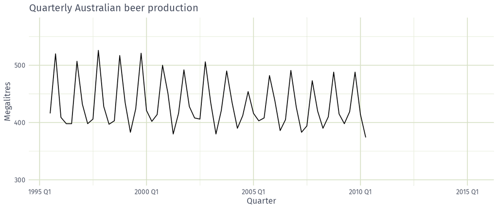

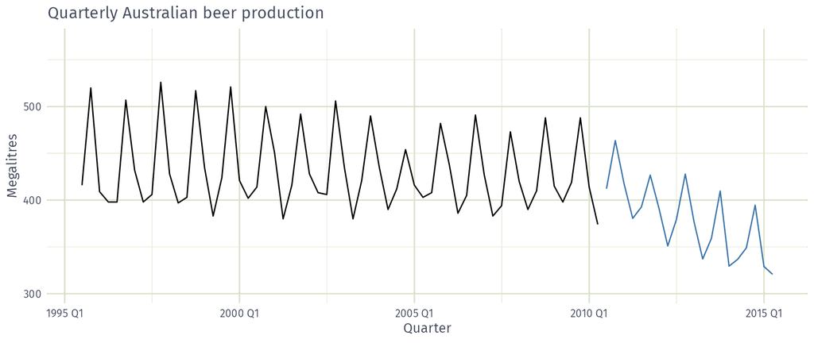

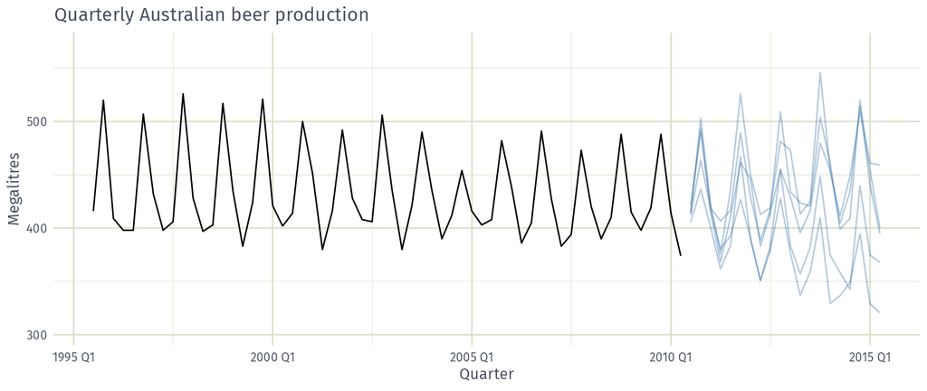

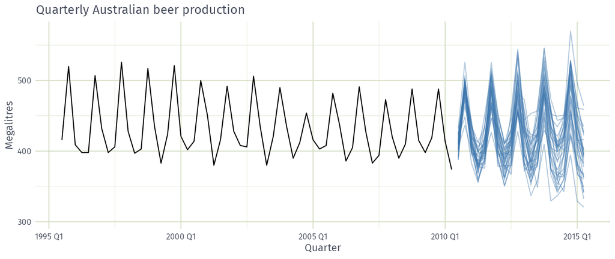

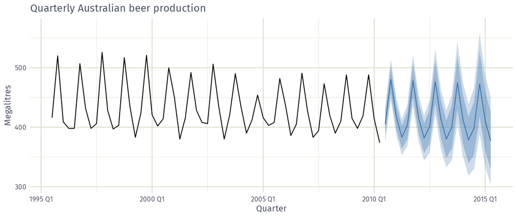

## What data do we need?

1. Historical data on the variable to forecast
2. Past and future values of predictors
   - Deterministic (e.g. holidays)
   - Stochastic (e.g. temperature)
3. Expert knowledge and context
   - New information

## Why forecast?

Why do you use forecasts?

| Decision | Forecast |
| --- | --- |
| Build a new hospital in the next 10 years? | Population and patient demand, years ahead |
| Call centre staff needed next week? | Call volumes, hours to days ahead |
| Vaccine doses needed next month? | Doses by region, weeks ahead |

The decision sets what to forecast and how far ahead.

## Forecasting workflow

[figure not shown]

## Packages for this course

**tidyverts.org**

[figure not shown]

Time series data

[figure not shown]

Example datasets

[figure not shown]

Features and decompositions

[figure not shown]

Time series graphics

[figure not shown]

Forecasting models

## Packages for this course

```r
# Data, graphics and forecasting
library(fpp3)
```

# Time series data

## Time series data

- Four-yearly Olympic winning times
- Annual Google profits
- Quarterly Australian beer production
- Monthly rainfall
- Weekly retail sales
- Daily IBM stock prices
- Hourly electricity demand
- 5-minute freeway traffic counts
- Time-stamped stock transaction data

## Your time series

What time series data do you work with?

## What makes it a time series?

Observations + when they happened.

- The time column is the index
- Observations are ordered in time
- Regular intervals define the frequency (yearly, quarterly, …)

# tsibble objects

## A `tsibble` has three parts

A tsibble stores one or more time series in a table.

- **Index**: when
- **Key**: which series (optional)
- **Measures**: what was observed

Works with dplyr verbs (`filter()`, `mutate()`, …).

## `tsibble` objects

```r
global_economy
```

```
# A tsibble: 15,150 x 6 [1Y]
# Key:       Country [263]
    Year Country             GDP Imports Exports Population
   <dbl> <fct>             <dbl>   <dbl>   <dbl>      <dbl>
 1  1960 Afghanistan  537777811.    7.02    4.13    8996351
 2  1961 Afghanistan  548888896.    8.10    4.45    9166764
 3  1962 Afghanistan  546666678.    9.35    4.88    9345868
 4  1963 Afghanistan  751111191.   16.9     9.17    9533954
 5  1964 Afghanistan  800000044.   18.1     8.89    9731361
 6  1965 Afghanistan 1006666638.   21.4    11.3     9938414
 7  1966 Afghanistan 1399999967.   18.6     8.57   10152331
 8  1967 Afghanistan 1673333418.   14.2     6.77   10372630
 9  1968 Afghanistan 1373333367.   15.2     8.90   10604346
10  1969 Afghanistan 1408888922.   15.0    10.1    10854428
# ℹ 15,140 more rows
```

Index

Key

Measures

## `tsibble` objects

```r
tourism
```

```
# A tsibble: 24,320 x 5 [1Q]
# Key:       Region, State, Purpose [304]
   Quarter Region   State Purpose  Trips
     <qtr> <chr>    <chr> <chr>    <dbl>
 1 1998 Q1 Adelaide SA    Business  135.
 2 1998 Q2 Adelaide SA    Business  110.
 3 1998 Q3 Adelaide SA    Business  166.
 4 1998 Q4 Adelaide SA    Business  127.
 5 1999 Q1 Adelaide SA    Business  137.
 6 1999 Q2 Adelaide SA    Business  200.
 7 1999 Q3 Adelaide SA    Business  169.
 8 1999 Q4 Adelaide SA    Business  134.
 9 2000 Q1 Adelaide SA    Business  154.
10 2000 Q2 Adelaide SA    Business  169.
# ℹ 24,310 more rows
```

Index

Keys

Measure

Overnight trips (thousands), quarterly, by region and purpose of travel.

## The `tsibble` index

For annual data, integer years work as the index:

```r
annual_data <- tsibble(
  year = 2012:2016,
  y = c(123, 39, 78, 52, 110),
  index = year
)
annual_data
```

```
# A tsibble: 5 x 2 [1Y]
   year     y
  <int> <dbl>
1  2012   123
2  2013    39
3  2014    78
4  2015    52
5  2016   110
```

## The `tsibble` index

```r
monthly_data
```

```
# A tibble: 5 × 2
  Month    Observation
  <chr>          <dbl>
1 2019 Jan          50
2 2019 Feb          23
3 2019 Mar          34
4 2019 Apr          30
5 2019 May          25
```

- `"2019 Jan"` is just text
- More frequent than yearly? Use a time class

## The `tsibble` index

```r
monthly_data |>
  mutate(Month = yearmonth(Month)) |>
  as_tsibble(index = Month)
```

```
# A tsibble: 5 x 2 [1M]
     Month Observation
     <mth>       <dbl>
1 2019 Jan          50
2 2019 Feb          23
3 2019 Mar          34
4 2019 Apr          30
5 2019 May          25
```

## The `tsibble` index

Common time index variables can be created with these functions:

| Frequency | Function |
| --- | --- |
| Annual | `start:end` |
| Quarterly | `yearquarter()` |
| Monthly | `yearmonth()` |
| Weekly | `yearweek()` |
| Daily | `as_date()`, `ymd()` |
| Sub-daily | `as_datetime()`, `ymd_hms()` |

## Converting dates

Often data is provided as dates, even if it isn’t daily.

```r
my_date <- as.Date("2026-10-01")
yearquarter(my_date)
```

```
<yearquarter[1]>
[1] "2026 Q4"
# Year starts on: January
```

```r
yearmonth(my_date)
```

```
<yearmonth[1]>
[1] "2026 Oct"
```

```r
yearweek(my_date)
```

```
<yearweek[1]>
[1] "2026 W40"
# Week starts on: Monday
```

## Looking ahead: `mixtime`

[figure not shown]

One family of linear time classes, including `year()` and `datetime()`:

```r
library(mixtime)
c(year(my_date), yearquarter(my_date), yearmonth(my_date), date(my_date))
```

```
<mixtime[4]>
[1] 2026       2026 Q4    2026 Oct   2026-10-01
```

Any granularity: pick a chronon (one time step) and call `linear_time()`:

```r
quarter_hours <- datetime("2024-01-01 00:00:00") + minutes(0:3) * 15L
linear_time(quarter_hours, chronon = cal_gregorian$minute(15L))
```

```
<mixtime[4]>
[1] 2024-01-01 00:00 2024-01-01 00:15 2024-01-01 00:30 2024-01-01 00:45
```

- `yearmonth(my_date)` is `linear_time(my_date, chronon = cal_gregorian$month(1L))`

## Looking ahead: `mixtime`

[figure not shown]

More time types, beyond this course:

```r
# Timezones
datetime(as.POSIXct("2026-10-05 22:30", tz = "UTC"), tz = "Africa/Nairobi")
```

```
<mixtime[1]>
[1] 2026-10-06 01:30:00 EAT
```

```r
# Other calendars (also cal_isoweek, lunar and solar calendars)
linear_time(my_date, chronon = cal_sym454$month(1L))
```

```
<mixtime[1]>
[1] 2026-Oct
```

```r
# Cyclical time
day_of_week(my_date)
```

```
<mixtime[1]>
[1] Thu
```

```r
# Durations
yearmonth(my_date) + months(0:2)
```

```
<mixtime[3]>
[1] 2026 Oct 2026 Nov 2026 Dec
```

## What a `tsibble` checks

- Index + key must uniquely identify each row: `as_tsibble()` errors on duplicates (find them with `duplicates()`)
- The interval is shown in the header: `[1Y]`, `[1Q]`, `[1M]`, …
- Missing time steps are implicit gaps: find them with `has_gaps()`, make them explicit with `fill_gaps()`

```r
tsibble(year = c(2012, 2013, 2015, 2016), y = c(123, 39, 52, 110), index = year) |>
  fill_gaps()
```

```
# A tsibble: 5 x 2 [1Y]
   year     y
  <dbl> <dbl>
1  2012   123
2  2013    39
3  2014    NA
4  2015    52
5  2016   110
```

# Example: Australian prison population

## Australian prison population

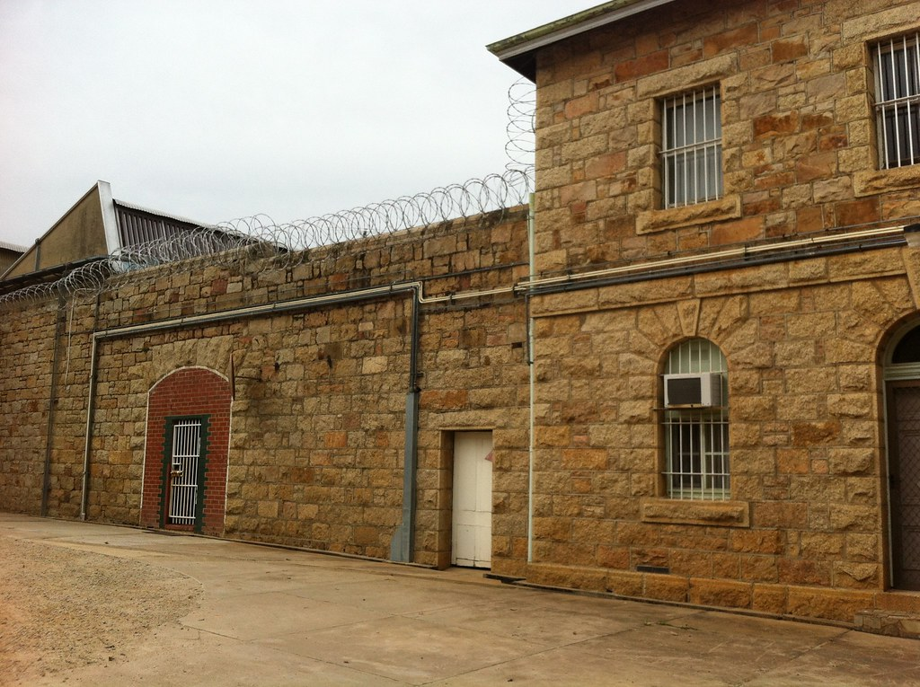

## Read a csv file

Quarterly prisoner counts from the ABS, 2005 Q1 to 2016 Q4, by state, gender, legal status and indigenous status (ATSI: Aboriginal and Torres Strait Islander).

```r
prison <- readr::read_csv("data/prison_population.csv")
```

```
# A tibble: 3,072 × 6
   date       state gender legal     indigenous count
   <date>     <chr> <chr>  <chr>     <chr>      <dbl>
 1 2005-03-01 ACT   Female Remanded  ATSI           0
 2 2005-03-01 ACT   Female Remanded  Other          2
 3 2005-03-01 ACT   Female Sentenced ATSI           0
 4 2005-03-01 ACT   Female Sentenced Other          0
 5 2005-03-01 ACT   Male   Remanded  ATSI           7
 6 2005-03-01 ACT   Male   Remanded  Other         58
 7 2005-03-01 ACT   Male   Sentenced ATSI           0
 8 2005-03-01 ACT   Male   Sentenced Other          0
 9 2005-03-01 NSW   Female Remanded  ATSI          51
10 2005-03-01 NSW   Female Remanded  Other        131
# ℹ 3,062 more rows
```

## Convert to a time class

```r
prison <- readr::read_csv("data/prison_population.csv") |>
  mutate(quarter = yearquarter(date))
```

```
# A tibble: 3,072 × 7
   date       state gender legal     indigenous count quarter
   <date>     <chr> <chr>  <chr>     <chr>      <dbl>   <qtr>
 1 2005-03-01 ACT   Female Remanded  ATSI           0 2005 Q1
 2 2005-03-01 ACT   Female Remanded  Other          2 2005 Q1
 3 2005-03-01 ACT   Female Sentenced ATSI           0 2005 Q1
 4 2005-03-01 ACT   Female Sentenced Other          0 2005 Q1
 5 2005-03-01 ACT   Male   Remanded  ATSI           7 2005 Q1
 6 2005-03-01 ACT   Male   Remanded  Other         58 2005 Q1
 7 2005-03-01 ACT   Male   Sentenced ATSI           0 2005 Q1
 8 2005-03-01 ACT   Male   Sentenced Other          0 2005 Q1
 9 2005-03-01 NSW   Female Remanded  ATSI          51 2005 Q1
10 2005-03-01 NSW   Female Remanded  Other        131 2005 Q1
# ℹ 3,062 more rows
```

## Remove the old date column

```r
prison <- readr::read_csv("data/prison_population.csv") |>
  mutate(quarter = yearquarter(date)) |>
  select(-date)
```

```
# A tibble: 3,072 × 6
   state gender legal     indigenous count quarter
   <chr> <chr>  <chr>     <chr>      <dbl>   <qtr>
 1 ACT   Female Remanded  ATSI           0 2005 Q1
 2 ACT   Female Remanded  Other          2 2005 Q1
 3 ACT   Female Sentenced ATSI           0 2005 Q1
 4 ACT   Female Sentenced Other          0 2005 Q1
 5 ACT   Male   Remanded  ATSI           7 2005 Q1
 6 ACT   Male   Remanded  Other         58 2005 Q1
 7 ACT   Male   Sentenced ATSI           0 2005 Q1
 8 ACT   Male   Sentenced Other          0 2005 Q1
 9 NSW   Female Remanded  ATSI          51 2005 Q1
10 NSW   Female Remanded  Other        131 2005 Q1
# ℹ 3,062 more rows
```

## Declare the index and keys

```r
prison <- readr::read_csv("data/prison_population.csv") |>
  mutate(quarter = yearquarter(date)) |>
  select(-date) |>
  as_tsibble(
    index = quarter,
    key = c(state, gender, legal, indigenous)
  )
```

```
# A tsibble: 3,072 x 6 [1Q]
# Key:       state, gender, legal, indigenous [64]
   state gender legal    indigenous count quarter
   <chr> <chr>  <chr>    <chr>      <dbl>   <qtr>
 1 ACT   Female Remanded ATSI           0 2005 Q1
 2 ACT   Female Remanded ATSI           1 2005 Q2
 3 ACT   Female Remanded ATSI           0 2005 Q3
 4 ACT   Female Remanded ATSI           0 2005 Q4
 5 ACT   Female Remanded ATSI           1 2006 Q1
 6 ACT   Female Remanded ATSI           1 2006 Q2
 7 ACT   Female Remanded ATSI           1 2006 Q3
 8 ACT   Female Remanded ATSI           0 2006 Q4
 9 ACT   Female Remanded ATSI           0 2007 Q1
10 ACT   Female Remanded ATSI           1 2007 Q2
# ℹ 3,062 more rows
```

# Example: Australian pharmaceutical sales

## Australian Pharmaceutical Benefits Scheme

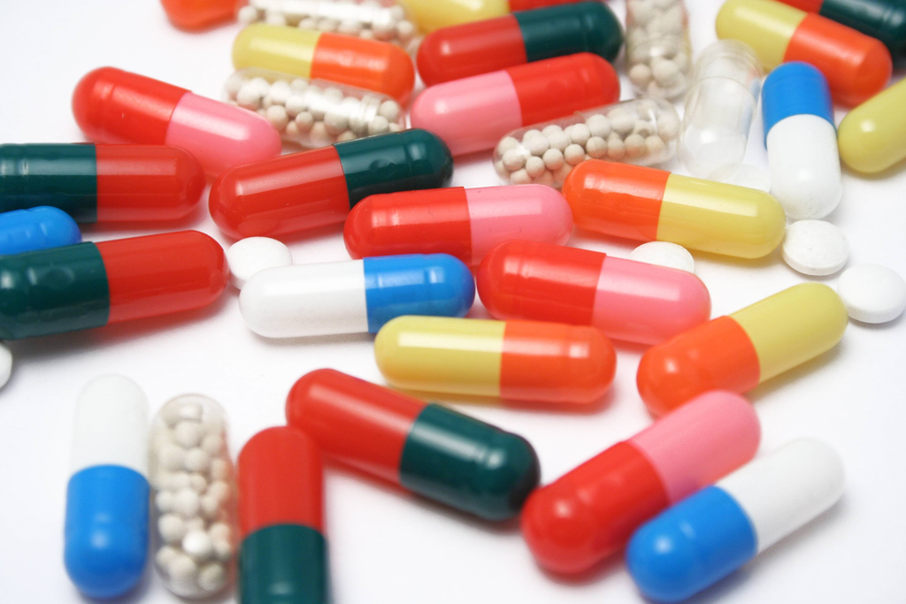

## Australian Pharmaceutical Benefits Scheme

The PBS is the Australian government drug subsidy scheme.

- Subsidises many pharmacy drugs
- Cost the government A$19.1 billion in 2024–25 (about 0.7% of GDP)
- Budget relies on forecasts of drug usage

`PBS` data: monthly, July 1991 to June 2008

- `Scripts` (prescriptions) and `Cost` (A$)
- By drug type (ATC2 x84), concession (x2) and patient type (x2)
- ATC: Anatomical Therapeutic Chemical classification

## Working with `tsibble` objects

```r
PBS
```

```
# A tsibble: 67,596 x 9 [1M]
# Key:       Concession, Type, ATC1, ATC2 [336]
      Month Concession   Type        ATC1  ATC1_desc                   ATC2  ATC2_desc Scripts  Cost
      <mth> <chr>        <chr>       <chr> <chr>                       <chr> <chr>       <dbl> <dbl>
 1 1991 Jul Concessional Co-payments A     Alimentary tract and metab… A01   STOMATOL…   18228 67877
 2 1991 Aug Concessional Co-payments A     Alimentary tract and metab… A01   STOMATOL…   15327 57011
 3 1991 Sep Concessional Co-payments A     Alimentary tract and metab… A01   STOMATOL…   14775 55020
 4 1991 Oct Concessional Co-payments A     Alimentary tract and metab… A01   STOMATOL…   15380 57222
 5 1991 Nov Concessional Co-payments A     Alimentary tract and metab… A01   STOMATOL…   14371 52120
 6 1991 Dec Concessional Co-payments A     Alimentary tract and metab… A01   STOMATOL…   15028 54299
 7 1992 Jan Concessional Co-payments A     Alimentary tract and metab… A01   STOMATOL…   11040 39753
 8 1992 Feb Concessional Co-payments A     Alimentary tract and metab… A01   STOMATOL…   15165 54405
 9 1992 Mar Concessional Co-payments A     Alimentary tract and metab… A01   STOMATOL…   16898 61108
10 1992 Apr Concessional Co-payments A     Alimentary tract and metab… A01   STOMATOL…   18141 65356
# ℹ 67,586 more rows
```

## `filter()`: choose rows

```r
PBS |>
  filter(ATC2 == "A10")
```

```
# A tsibble: 816 x 9 [1M]
# Key:       Concession, Type, ATC1, ATC2 [4]
      Month Concession   Type        ATC1  ATC1_desc                  ATC2  ATC2_desc Scripts   Cost
      <mth> <chr>        <chr>       <chr> <chr>                      <chr> <chr>       <dbl>  <dbl>
 1 1991 Jul Concessional Co-payments A     Alimentary tract and meta… A10   ANTIDIAB…   89733 2.09e6
 2 1991 Aug Concessional Co-payments A     Alimentary tract and meta… A10   ANTIDIAB…   77101 1.80e6
 3 1991 Sep Concessional Co-payments A     Alimentary tract and meta… A10   ANTIDIAB…   76255 1.78e6
 4 1991 Oct Concessional Co-payments A     Alimentary tract and meta… A10   ANTIDIAB…   78681 1.85e6
 5 1991 Nov Concessional Co-payments A     Alimentary tract and meta… A10   ANTIDIAB…   70554 1.69e6
 6 1991 Dec Concessional Co-payments A     Alimentary tract and meta… A10   ANTIDIAB…   75814 1.84e6
 7 1992 Jan Concessional Co-payments A     Alimentary tract and meta… A10   ANTIDIAB…   64186 1.56e6
 8 1992 Feb Concessional Co-payments A     Alimentary tract and meta… A10   ANTIDIAB…   75899 1.73e6
 9 1992 Mar Concessional Co-payments A     Alimentary tract and meta… A10   ANTIDIAB…   89445 2.05e6
10 1992 Apr Concessional Co-payments A     Alimentary tract and meta… A10   ANTIDIAB…   97315 2.23e6
# ℹ 806 more rows
```

## `select()`: choose columns

```r
PBS |>
  filter(ATC2 == "A10") |>
  select(Month, Concession, Type, Cost)
```

```
# A tsibble: 816 x 4 [1M]
# Key:       Concession, Type [4]
      Month Concession   Type           Cost
      <mth> <chr>        <chr>         <dbl>
 1 1991 Jul Concessional Co-payments 2092878
 2 1991 Aug Concessional Co-payments 1795733
 3 1991 Sep Concessional Co-payments 1777231
 4 1991 Oct Concessional Co-payments 1848507
 5 1991 Nov Concessional Co-payments 1686458
 6 1991 Dec Concessional Co-payments 1843079
 7 1992 Jan Concessional Co-payments 1564702
 8 1992 Feb Concessional Co-payments 1732508
 9 1992 Mar Concessional Co-payments 2046102
10 1992 Apr Concessional Co-payments 2225977
# ℹ 806 more rows
```

## `summarise()`: combine over keys

```r
PBS |>
  filter(ATC2 == "A10") |>
  select(Month, Concession, Type, Cost) |>
  summarise(total_cost = sum(Cost))
```

```
# A tsibble: 204 x 2 [1M]
      Month total_cost
      <mth>      <dbl>
 1 1991 Jul    3526591
 2 1991 Aug    3180891
 3 1991 Sep    3252221
 4 1991 Oct    3611003
 5 1991 Nov    3565869
 6 1991 Dec    4306371
 7 1992 Jan    5088335
 8 1992 Feb    2814520
 9 1992 Mar    2985811
10 1992 Apr    3204780
# ℹ 194 more rows
```

## `mutate()`: create variables

```r
PBS |>
  filter(ATC2 == "A10") |>
  select(Month, Concession, Type, Cost) |>
  summarise(total_cost = sum(Cost)) |>
  mutate(cost_m = total_cost / 1e6)
```

```
# A tsibble: 204 x 3 [1M]
      Month total_cost cost_m
      <mth>      <dbl>  <dbl>
 1 1991 Jul    3526591   3.53
 2 1991 Aug    3180891   3.18
 3 1991 Sep    3252221   3.25
 4 1991 Oct    3611003   3.61
 5 1991 Nov    3565869   3.57
 6 1991 Dec    4306371   4.31
 7 1992 Jan    5088335   5.09
 8 1992 Feb    2814520   2.81
 9 1992 Mar    2985811   2.99
10 1992 Apr    3204780   3.20
# ℹ 194 more rows
```

`cost_m` is the total cost in A$ millions.

## Save the result

```r
a10 <- PBS |>
  filter(ATC2 == "A10") |>
  select(Month, Concession, Type, Cost) |>
  summarise(total_cost = sum(Cost)) |>
  mutate(cost_m = total_cost / 1e6)
```

```
# A tsibble: 204 x 3 [1M]
      Month total_cost cost_m
      <mth>      <dbl>  <dbl>
 1 1991 Jul    3526591   3.53
 2 1991 Aug    3180891   3.18
 3 1991 Sep    3252221   3.25
 4 1991 Oct    3611003   3.61
 5 1991 Nov    3565869   3.57
 6 1991 Dec    4306371   4.31
 7 1992 Jan    5088335   5.09
 8 1992 Feb    2814520   2.81
 9 1992 Mar    2985811   2.99
10 1992 Apr    3204780   3.20
# ℹ 194 more rows
```

## Plot the result

```r
autoplot(a10, cost_m) +
  labs(y = "A$ (millions)", title = "Australian antidiabetic drug sales")
```

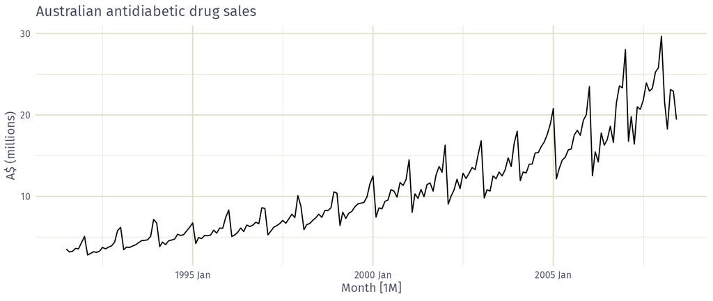

## Your turn

**Using `tourism`**

1. Find the quarterly total `Trips` for each `State`
2. **Challenge:** Which `State` had the most `Trips` over the whole period?

**Using `PBS`**

3. Find the total monthly `Scripts` for ATC2 `"H02"`

**Hints**

- `summarise()` always keeps the index
- Q1: `group_by(State)`, then `summarise()`
- Q2: `as_tibble()` first: it drops the tsibble structure, so `summarise()` no longer keeps the index
- Q3: `filter()`, then `summarise()`

## Recap

- A tsibble has an **index**, **keys** and **measures**
- Index + keys uniquely identify each row
- The index needs a time class (`yearmonth()`, `as_date()`, …)
- Use dplyr verbs to wrangle tsibbles
- `summarise()` combines over keys, keeping the index